# 2018-09-14 첫 번째 수업

김권현

2018년 9월 14일

# HBE01239: 응용데이터사이언스(5733)

- 담당교수 : 김권현
- 강의시간 : 금요일 오후 1:30 - 4:15
- 강의장소 : S1353
- 상담시간 : 금요일 수업 전후(이메일로 사전 약속 필요)
- 선수과목 : R통계분석

## 교과목 개요

’R통계분석’에 기초하여 상위 과정의 R 사용법과 프로그래밍 능력을 배양한다.

## 성적평가방법

출석(20), 과제물/보고서(20), 수시시험 및 중간고사(20), 학기말시험(20), 발표(20)

## R markdown

- [R markdown](https://rmarkdown.rstudio.com/lesson-1.html)

## 깃헙(github) 관련

- [github](https://github.com/) id를 만든다.
- [수업 레포지토리](https://github.com/kwhkim/MJU-2018-02-DataScience)를 fork한다.
- Rstudio - New Project - Version Control - Git - Clone Git Repository
- [git-scm download](https://git-scm.com/downloads)
- 자신의 수정 사항 Git에 올리기 : Stage - Commit - Push – New Pull Request
- Configuring a remote for a fork(**이때 주의할 점은 cd 명령어를 통해 자신의 project 폴더로 이동한 후 다음의 명령을 실행해야 합니다.**)

```
     $ cd D:/GDrive/Lecture/MJU-2018-02-DataScience(여기에 자신의 폴더를 넣습니다.)
     $ git remote -v
     $ git remote add upstream https://github.com/kwhkim/MJU-2018-02-DataScience.git
     $ git remote -v
```

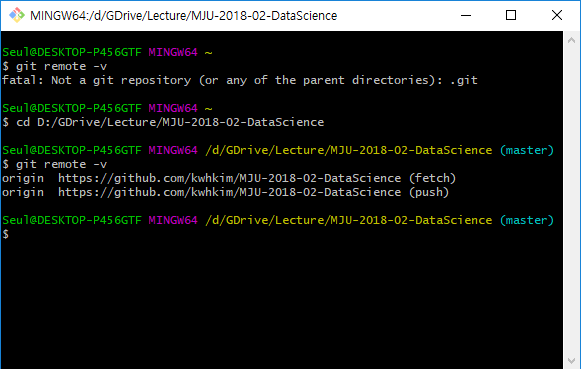

git remote를 하기 전에 cd로 현재 폴더를 프로젝트가 저장된 폴더로 바꾸세요.

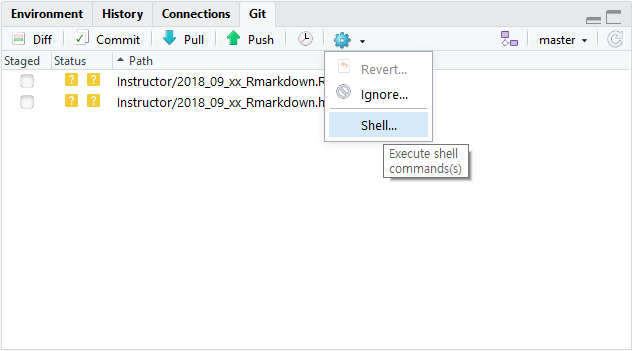

git 탭의 Shell 선택하기: R Studio의 오른쪽 git 탭에서 Shell을 선택하거나, 주메뉴의 Tools-Shell을 선택하면 Git Bash가 실행되고 R 프로젝트 폴더로 자동 이동합니다.

- Syncing a fork

```
     $ git fetch upstream
     $ git checkout master
     $ git merge upstream/master
```

## 데이터

- [공공데이터포털](https://www.data.go.kr/)
- [서울열린데이터광장](http://data.seoul.go.kr/)
- [UCI Machine Learning Repository](https://archive.ics.uci.edu/ml/index.php)
- www.statsci.org
- [Kaggle](https://www.kaggle.com/)
- [FRED, Economic Research](https://fred.stlouisfed.org/)
- [the National Bureau of Economic Research](http://www.nber.org/data/)
- [통계지리정보서비스](https://sgis.kostat.go.kr/view/index)
- [Journal of open psychology data](https://openpsychologydata.metajnl.com/)
- [Academic Torrents](http://academictorrents.com/)

## 통계학과 R 관련 자료

- [R과 함께 하는 통계학의 이해](http://www.bigbook.or.kr/bbs/bbs/board.php?bo_table=bo16&sca=&sfl=wr_subject&stx=%C5%EB%B0%E8%C7%D0%C0%C7+%C0%CC%C7%D8&x=0&y=0)
- [Learning statistics with R](http://www.fon.hum.uva.nl/paul/lot2015/Navarro2014.pdf)
- [Quick-R](https://www.statmethods.net/about/sitemap.html)
- [r4stats](http://r4stats.com)
- r-tutor
- [Introduction to Statistical Thought](http://people.math.umass.edu/~lavine/Book/book.pdf)
- [Data Science Books](http://www.wzchen.com/data-science-books/)
- [Free Stats e-book](https://www.r-statistics.com/2009/10/free-statistics-e-books-for-download/)

## R로 데이터 불러들이기(Importing Data)

- http://r4stats.com/examples/data-import/
- http://www.r-tutor.com/r-introduction/data-frame/data-import
- http://www.cookbook-r.com/Data_input_and_output/Loading_data_from_a_file/